# BBVA Éxito - Reporte de Encuestas

Magdalena Bennett[^1]

William Fuchs[^2]

Jaime Millán[^3]

Marzo 01, 2023

# Introducción

El acceso al microcrédito en contextos donde el apoyo financiero no está disponible para las personas marginadas puede ser una política importante para apoyar el bienestar de las poblaciones vulnerables. Una pregunta importante, sin embargo, es cómo seleccionan mejor las instituciones a las personas a quienes otorgar crédito y, lo que es más importante, si hay formas en que puedan apoyarlas para que tengan éxito.

En este proyecto, abordaremos estas dos preguntas al identificar las características comunes que comparten los microempresarios exitosos utilizando un gran conjunto de datos históricos de una institución de microcrédito y al crear intervenciones para apoyar y promover algunas de estas características procesables en otros prestatarios de microcréditos. Para ello, nos asociamos con la Fundación BBVA, institución que está presente a través de diferentes entidades en varios países de América Latina y otorga microcréditos a emprendedores vulnerables. Las contribuciones esperadas de este proyecto son identificar y generar evidencia relacionada con algunos de los determinantes del éxito en el contexto de los microcréditos, y determinar cómo las instituciones pueden apoyar a las personas para ayudarlos a tener éxito en sus negocios. También esperamos arrojar luz sobre otras características que podrían ser útiles a la hora de elegir aprobar o no un crédito, lo que podría ser particularmente importante para poblaciones frecuentemente marginadas.

Estudiaremos los determinantes del éxito en el contexto de cuatro países diferentes de América Latina con un gran conjunto de datos de millones de microempresarios a lo largo de los años. Esto brinda una oportunidad única para analizar información a nivel individual en un área donde los datos suelen ser escasos. La mayoría de las personas de nuestra muestra provienen de entornos marginados, muchas veces sin acceso al crédito a través de instituciones privadas, y de áreas rurales en sus respectivos países. Si bien nuestro análisis se centrará en América Latina, esperamos que algunos de estos resultados puedan generalizarse a otras poblaciones del mundo, dado que los pequeños empresarios a menudo enfrentan desafíos similares.

El estudio se divide en dos fases: (1) identificación de las características asociadas con el éxito y (2) intervenciones destinadas a mejorar las posibilidades de éxito. La idea principal es que la fase 1 de este estudio informa las intervenciones para la fase 2. En particular, este reporte se refiere a los resultados de la primera parte del estudio (fase 1).

La primera parte del estudio (fase 1) será retrospectiva. Nos enfocaremos en los clientes existentes para identificar las características que están asociadas con el éxito, medido tanto como el pago oportuno del crédito, así como el aumento de sus activos y negocios en general. En términos de datos, esta fase del estudio se basa en datos históricos proporcionados por la Fundación BBVA desde 2013 hasta 2021. Este es un conjunto de datos único ya que contiene millones de clientes de microcrédito en América Latina. Lo complemetamos con encuestas aplicadas a una muestra representativa de clientes existentes (n = 2,200). Utilizando estos datos, identificaremos características compartidas para el grupo categorizado como individuos “exitosos” y dividiremos estos atributos en categorías procesables y no procesables. Aunque las características identificadas en la fase 1 no proporcionarán evidencia causal de los determinantes del éxito, ayudarán a informar el diseño de diferentes intervenciones que se probarán en la segunda parte de este estudio (fase 2).

# Selección de Muestra y Diseño Encuestas

En base a los datos entregados por la Fundación BBVA, se categorizaron a los clientes en base a su nivel de éxito (e.g. Exitoso, No Exitoso, Un crédito, Sin información). Para los clientes con más de un crédito, fueron categorizados como exitosos aquellos microemprendedores sin mora y cuyo capital había crecido entre un crédito y otro crédito; de igual forma, clientes con mora o sin crecimiento fueron categorizados como no exitosos. Se incluyó también en la muestra una lista reducida de clientes que las oficinas calificaron como Exitosos según sus propias medidas, siendo clasificados como exitosos subjetivos. A continuación se describen las categorías utilizadas en el análisis, donde todos las categorías a excepción de “No exitoso” son considerados “Exitosos”:

- **Exitoso** (más de un crédito): Cliente con más de un crédito entre 2018 y 2020, sin mora y cuyo capital creció entre el primer crédito y el último.
- **No exitoso**: Cliente con más de un crédito entre 2018 y 2020, y que estuvo moroso en el periodo o cuyo capital no creció entre el primer y último crédito.
- **Un crédito**: Clientes con un solo crédito entre 2018 y 2021 que no contaron con mora durante el periodo de estudio. Esta categoría se refiere potencialmente a clientes “fugados”.
- **Subjetivos**: Clientes propuestos por cada oficina local de los microemprendedores que ellos consideran exitosos.

Las encuestas se realizaron en 4 países de América Latina (Colombia, Panamá, Perú, y República Dominicana), con aproximadamente 600 encuestas en cada país, con excepción de Panamá, donde solo se realizaron 400 encuestas[^4]. Para lograr representatividad en cuanto a los tipos de clientes, se tomaron muestras representativas de las distintas categorías (con excepción de los subjetivos, que eran propuestos directamente por las oficinas), estratificados también por su área de negocio (Agrícola o No Agrícola). La muestra fue seleccionada también de manera representativa en términos de geografía, para abarcar distintas zonas del país.

A continuación se muestran los resultados agregados para todos los países.

# Resultados

## Descripción general

En total, se realizaron 2121 encuestas en todos los países como muestra el siguiente mapa interactivo. En el caso de Colombia, se realizaron 523 encuestas en diversas zonas del país, como muestra el siguiente mapa. Varias encuestas se concentran en Bogotá y Medellín, pero otras zonas del país también fueron cubiertas. En Panamá, se completaron 400 encuestas, tanto en la zona este como la zona oeste del país. En Perú, se realizaron 593, principalmente en Lima, pero también en varias zonas rurales. Finalmente, en República Dominicana 605 clientes respondieron la encuesta.

[interactive chart not shown]

Figura 1. Localización geográfica de encuestas en Colombia

Las encuestas fueron estratificadas según diferentes categorias: Exitoso, No exitoso, Un contrato, y Subjetivos. Además, dichas categorías fueron separadas según el tipo de actividad del cliente (agrícola o no agricola). La siguiente tabla muestra el número de encuestas por categoría:

Tabla 1. Distribución de encuestas realizadas por categoría de Éxito

| Categoría | N Encuestas |
| --- | --- |
| Exitoso - Agro | 124 |
| Exitoso - No Agro | 724 |
| No Exitoso - Agro | 193 |
| No Exitoso - No Agro | 594 |
| Subjetivo | 45 |
| Un Contrato - Agro | 85 |
| Un Contrato - No Agro | 356 |

El trabajo de campo se realizó entre Junio 2022 y Enero del 2023, con un peak de encuestas en Octubre. Si bien la mayor parte del trabajo de campo se realizó en la mayoría de los países entre Septiembre y Noviembre, hubo ciertas variaciones dependiendo del país[^5].

[figure not shown]

Figura 2. Fechas de aplicación de encuesta

Respecto a la caracterización de los clientes que respondieron la encuesta, estos tienen en promedio 47, con un rango entre 20 y 80 años de edad.

[figure not shown]

Figura 3. Distribución de edad de los participantes

En general, tienen un nivel educacional bajo, donde la mayoría alcanzó un nivel de educación secundaria o menor. Si bien la distribución entre los grupos Exitosos y No Exitosos es similar, hay una leve diferencia en educación primaria y educación superior, donde los clientes clasificados como Exitosos tienden a completar mayores niveles de educación. También se observa una heterogeneidad importante entre países: Perú cuenta con clientes con mayor nivel educacional, mientras que en República Dominicana cerca de un cuarto de la muestra no reporta información educacional o reporta alguna otra alternativa.

[figure not shown]

Figura 4. Nivel educacional de los participantes según clasificación de Éxito

[figure not shown]

Figura 5. Nivel educacional de los participantes por país

En cuanto a las áreas de los negocios, los clientes que respondieron la encuesta se dedican principalmente al comercio al por menor, seguido por el negocios agrícolas y servicios:

[figure not shown]

Figura 6. Áreas de negocio de participantes

## Definición de Éxito

[figure not shown]

Figura 7. Se considera ud. exitoso?

Se les preguntó a los clientes de manera abierta por qué se consideraban exitosos, y la mayoría dio argumentos asociados al trabajo, logros y metas. La siguiente figura muestra una nube con las palabras más frecuentes en dicha respuesta. De los pocos clientes que declaran no considerarse exitosos, las palabras que más se repiten se refieren a metas, faltas, proyecto, e incluso la pandemia.

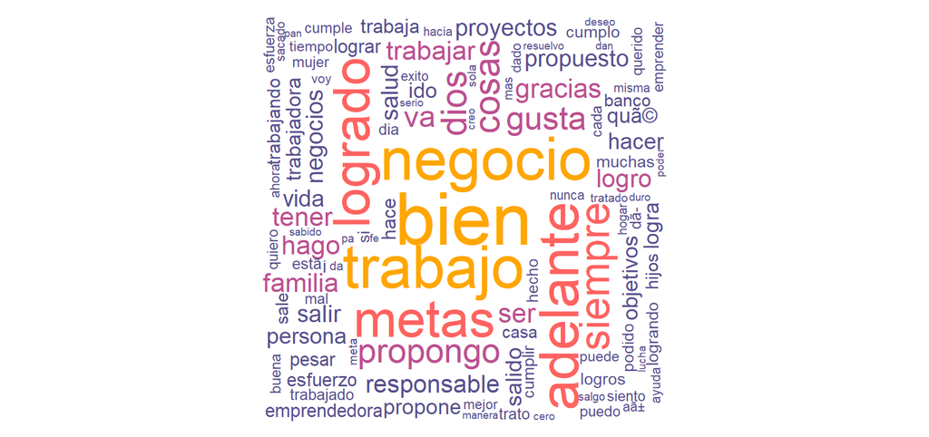

Figura 8. Nube de palabras para razones por las que se consideran exitosos/as

Para los pocos clientes que responden que no se sienten exitosos, la mayoría declara que se considerarían exitosos si es que lograran que su negocio fuera estable.

[figure not shown]

Figura 9. Para los que no se consideran exitosos - Se consideraría exitoso principalmente si antes de 5 años…

Para finalizar esta sección, se les preguntó a los participantes qué hace exitoso/a a una persona o a un negocio. La misma proporción de personas asocia el exito personal a la estabilidad del negocio como a la estabilidad del hogar. A la vez, cerca de un tercio de los clientes consideran que el éxito de un negocio recae en su crecimiento. Dichas respuestas son similares entre los clientes categorizados como exitosos y no exitosos, aunque clientes no exitosos tienden a darle mayor importancia al reconocimiento por la comunidad y al hecho que el negocio permita cubrir necesidades del hogar.

[figure not shown]

Figura 10. Percepción de persona y negocio exitoso

[figure not shown]

Figura 11. Percepción de persona y negocio exitoso por categoría

## Factores de Éxito

Para analizar potenciales factores de éxito, se les preguntó a los participantes qué harían con los beneficios de su negocio. La gran mayoría de clientes categorizados como exitosos como también los no exitosos respondieron que reinvertirían esas ganancias en su negocio. Alrededor de un tercio de los participantes declaran que usuarían esas ganancias para invertir en el hogar o pagar deudas. La distribución de respuestas es similar entre las dos categorías de éxito.

[figure not shown]

Figura 12. Cuando usted tiene beneficios en su negocio generalmente…

Según las respuestas de la encuesta, los participantes tienden a ser más optimistas que pesimistas, y una mayor proporción es menos aversa al riesgo. En cuanto a diferencias entre exitosos y no exitosos, las respuestas tienden a ser similares, con una propensión al riesgo levemente mayor para los clientes clasificados como no exitosos.

[figure not shown]

Figura 13. Preguntas acerca de optimismo y riesgo en los negocios

[figure not shown]

Figura 14. Preguntas acerca de optimismo y riesgo en los negocios según categoría de éxito

## Juegos de Riesgo

Finalmente, al finalizar la encuesta, se les preguntó a los encuestados si es que deseaban responder un par de preguntas adicionales que les permitirían ganar dinero real. Si es que aceptaban, el encuestador procedía con tres juegos distintos, y si es que no aceptaban, se les entregaba una cantidad fija de pago por su participación.

Los juegos realizados tienen como objetivo identificar el nivel de riesgo que los clientes están dispuestos a tomar. Para cada país se dieron premios correspondientes en la moneda local, con un valor esperado de los premios de alrededor de US$7.

### Juego I - Aversión al riesgo

El primer juego consiste en darle la opción al encuestado de escoger entre un valor fijo o un premio que depende del resultado de una moneda. El valor esperado del premio para cada opción es prácticamente constante, pero la varianza aumenta a medida que se avanza en las opciones. Los escenarios eran los siguientes:

1. (A): $5 seguro o (B): $4 si sale cara o $6.5 si sale sello
2. (A): $5 seguro o (B): $3 si sale cara o $8 si sale sello
3. (A): $5 seguro o (B): $2 si sale cara o $10 si sale sello
4. (A): $5 seguro o (B): $1 si sale cara o $12 si sale sello
5. (A): $5 seguro o (B): $0 si sale cara o $13 si sale sello

Se observa según las respuestas de los encuestados que si bien hay una distribución bastante uniforme en cuanto al riesgo, hay un porcentaje importante (22.3%) que tiene una mayor propensión al riesgo.

[figure not shown]

Figura 15. Respuestas en Juego I

Analizando las mismas distribuciones en términos de éxito, utilizamos un modelo lineal de probabilidades (LPM) para analizar la asociación entre riesgo y éxito[^6]:

$$Exito = \beta_0 + \beta_1Risk_1 +
\beta_2Risk_2 + \beta_3Risk_3 + \beta_4Risk_4+\beta_5Risk_5 +
\varepsilon$$
El coeficiente $\beta_0$ representa la probabilidad promedio de un cliente de ser categorizado como exitoso si es que no toma ningún riesgo (i.e. elige la opción de $5 fijo), mientras que $\beta_i$ representa la diferencia en probabilidad de ser considerado exitoso entre clientes que eligen la opción $i$ de riesgo vs los que no eligen arriesgarse. Si es que dichos coeficientes son estadísticamente distintos de cero, indicarían que hay una diferencia significativa entre clientes que toman distintos niveles de riesgo y su probabilidad de ser exitosos.

Como se observa en los siguientes resultados, no hay una diferencia significativa entre los distintos grupos de riesgo ($\beta_1$ a $\beta_5$).

[figure not shown]

Figura 16. Coeficientes LPM para aversión al riesgo

### Juego II - Aversión a la pérdida

En el segundo juego, se le entrega al encuestado $20 y se le da la oportunidad de ganar $10 más. Para esto, se le muestra los siguientes 5 escenarios en los cuales tiene que escoger una de las dos alternativas (A o B). Finalmente, se selecciona de manera aleatoria la opción que se jugará y recibe el pago de acuerdo a este resultado.

1. (A): No perder nada o (B): Ganar $10 más si sale cara o perder $20 si sale sello
2. (A): No perder nada o (B): Ganar $10 más si sale cara o perder $16 si sale sello
3. (A): No perder nada o (B): Ganar $10 más si sale cara o perder $12 si sale sello
4. (A): No perder nada o (B): Ganar $10 más si sale cara o perder $8 si sale sello
5. (A): No perder nada o (B): Ganar $10 más si sale cara o perder $4 si sale sello

En la siguiente figura se observa que los clientes que respondieron la encuesta son en gran parte aversos a la pérdida. Por ejemplo, en el primer escenario (mayor riesgo) solo un 37.6% estuvo dispuesto a tirar una moneda, y solo cuando se llega al quinto escenario (menor riesgo) la proporción de personas dispuestas a arriesgar se equipara con las que no están dispuestas.

[figure not shown]

Figura 17. Respuestas en Juego II

En base a dichas respuestas, construimos una variable de aversión a la pérdida, con niveles de 0 a 5, donde 0 representa la persona que nunca escoge lanzar la moneda, 1 la persona que decide arriesgarse en el caso menos riesgoso, etc. De la misma manera que en el caso anterior, utilizamos un modelo de probabilidad lineal:

$$Exito = \gamma_0 + \gamma_1Loss_1 +
\gamma_2Loss_2 + \gamma_3Loss_3 + \gamma_4Loss_4+\gamma_5Loss_5 +
\varepsilon$$
donde $\gamma_0$ representa la probabidad promedio de que una persona sea categorizada como exitosa si nunca apuesta, y $\gamma_i$ representa la diferencia en probabilidad de ser categorizado como exitoso entre las personas que deciden lanzar la moneda en el escenario $6-i$[^7].

En este caso se observa que si bien la mayoría de los coeficientes están en torno a 0, hay una diferencia significativa para los clientes que deciden apostar a las opciones de ganar $10 o perder $16 o incluso perder $20, las cuales son las opciones de mayor riesgo. Esto indica que clientes con menor aversión a la pérdida son categorizados como exitosos con una mayor probabilidad.

[figure not shown]

Figura 18. Coeficientes LPM para aversión a la pérdida

### Juego III - Honestidad

Finalmente, el último juego consiste en 10 rondas, donde el encuestado debe adivinar el número que mostrará un dado. La persona deberá pensar un número entre 1 y 6, se generará el número al azar, y después la persona ingresará el número que había pensado. Si el número es igual que el que se muestra, la persona gana $1; si no es igual, la persona no gana nada.

Este juego tiene como objetivo medir el nivel de honestidad de los participantes. En promedio, si es que los participantes responden de manera honesta, deberíamos observar una distribución de porcentaje de aciertos en torno al valor esperado real (e.g. acertar 1 de 6 veces, en promedio, o 16.7%). Para contrastar los resultados, realizamos 100 simulaciones bajos los mismos parámetros que el juego. En este caso, observamos que la distribución observda (en naranjo) está sesgada con respecto a la distribución simulada. La primera tiene una cola más larga hacia la derecha, demostrando que ciertos clientes probablemente mienten respecto a sus respuestas para obtener el dinero.

[figure not shown]

Utilizando el porcentaje de aciertos observados menos el porcentaje esperado (16.7%), construimos una variable categorica de honestidad de la siguiente manera:

1. $Hon_0$: La persona tiene un porcentaje de aciertos igual o menor a 20%
2. $Hon_1$: La persona tiene un porcentaje de aciertos mayor o igual a 20% y menor a 30%
3. $Hon_2$: La persona tiene un porcentaje de aciertos mayor o igual a 30% y menor a 40%
4. $Hon_3$: La persona tiene un porcentaje de aciertos mayor o igual a 40%

Al igual que en los dos juegos anteriores, usamos un modelo lineal de probabilidades para identificar la asociación entre honestidad y éxito:

$$Exito = \delta_0 + \delta_1Hon_1 +
\delta_2Hon_2 + \delta_3Hon_3 + \varepsilon$$

El coeficiente $\delta_0$ representa la probabilidad promedio de un cliente de ser categorizado como exitoso si es que es clasificado como honesto ($Hon_0=1$), mientras que $\delta_i$ representa la diferencia en probabilidad de ser considerado exitoso entre clientes clasificados con un nivel de honestidad $i$ vs los que caen en la categoria $Hon_0$.

Como se observa en los siguientes resultados, no hay una diferencia significativa entre los distintos grupos de honestidad.

[figure not shown]

# Predicción de Éxito

En esta sección utilizaremos distintos métodos de *Machine Learning* para entender mejor cuáles son las características que mejor predicen distintas definiciones de éxito. El objetivo es aprovechar la data detallada de las encuestas para identificar qué caracteristicas de los clientes están más altamente correlacionadas con éxito.

## Pago a tiempo y crecimiento

En esta primera definición de éxito, utilizamos la caracterización inicial de la encuesta, donde clientes con más de un crédito que crecieron entre su primer y último crédito y no tuvieron demora en sus pagos son categorizados como exitosos. En este caso, se excluye a los clientes con un solo crédito.

El primer modelo que utilizamos en un modelo lineal generalizado con regularización lasso. Esto permite seleccionar las características que más aportan a la predicción de la variable de resultado sin sobre-saturar el modelo. Si bien el modelo detecta variables que son intuitivamente relevantes, cabe notar que el nivel de exactitud del modelo es bajo, con un porcentaje de clasificación correcta de 59.2%.

[figure not shown]

Figura 21. Importancia relativa de variables en modelo de regularización lasso para preddicción de Éxito

Como segundo modelo, utilizamos un algoritmo de *Random Forest* para identificar de manera no paramétrica qué variables son las que más predicen la categoría de éxito. Al igual que en el ejercicio anterior, se repite el país (Panamá), si realiza negocios con una asociación y/o cooperativa, si adquirió experience a través de capacitaciones, y si su medio de transporte es la moto.

[figure not shown]

Figura 22. Importancia relativa de variables en modelo de random forest para preddicción de Éxito

[^1]: University of Texas at Austin, m.bennett@austin.utexas.edu
[^2]: University of Texas at Austin, william.fuchs@mccombs.utexas.edu
[^3]: Universidad de Navarra, jmillan@…
[^4]: Debido a problemas de paralizaciones y cortes de camino durante el trabajo de campo, se tuvo que limitar la muestra original
[^5]: Debido a huelgas nacionales en Panamá, se tuvo que extender el trabajo de campo a Diciembre y Enero, mientras que Perú cerró la primera semana de Diciembre.
[^6]: En este caso, excluímos a clientes con un solo contrato
[^7]: En este caso, como el escenario 1 es el más riesgoso y el escenario 5 es el menos riesgoso, se indexan las opciones según menor riesgo (1) a mayor riesgo (5)